# assignment 3

Amir Ghoabdi

2024-05-07

# Question 1

```r
library(mgcv)
```

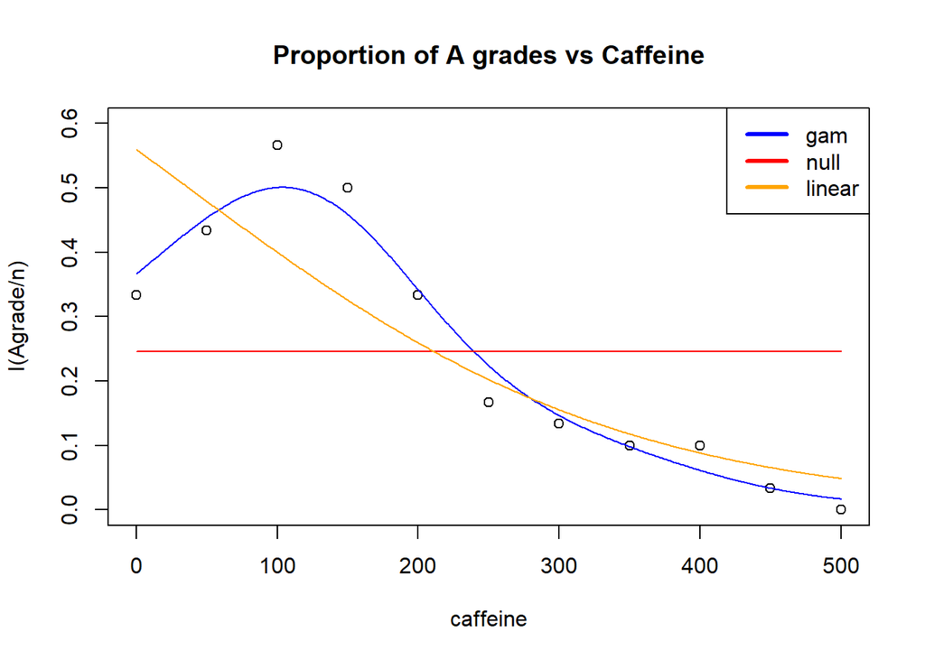

```r
Caffeine.df <- read.csv("Caffeine.csv")

## null model (order 0)
mod.0=glm(cbind(Agrade,n-Agrade)~1, family=binomial,
data =Caffeine.df)
## linear (order 1)
mod.1=glm(cbind(Agrade,n-Agrade)~caffeine,
family=binomial, data =Caffeine.df)
## quadratic (order 2)
mod.2=glm(cbind(Agrade,n-Agrade)~caffeine+I(caffeine^2),
family=binomial, data =Caffeine.df)
## cubic (order 2)
mod.3=glm(cbind(Agrade,n-Agrade)~caffeine +I(caffeine^2)+I(caffeine^3),
family=binomial, data =Caffeine.df)
mod.gam=gam(cbind(Agrade,n-Agrade)~s(caffeine),
family=binomial, data =Caffeine.df)
# look at null, order 1 and GAM fits (adapt this below )
plot(I(Agrade/n)~caffeine, ylim=c(0,.6),
main ="Proportion of A grades vs Caffeine", data=Caffeine.df)
# add lines
caffs=seq(0, 500, by=1)
new.df=data.frame(caffeine=caffs)
p.gam=predict(mod.gam, newdata=new.df,type="response")
lines(caffs, p.gam, col="blue")
p0=predict(mod.0, newdata=new.df, type="response")
lines(caffs, p0, col="red")
p1=predict(mod.1, newdata=new.df, type="response")
lines(caffs, p1, col="orange")
legend('topright', lty=1,lwd=3, col=c("blue", "red","orange") ,
legend=c("gam", "null","linear"))
```

# A)

The model above shows the relationship between coffee consumption and students test grade with three models including : null model, a linear model, and a generalized additive model (GAM) shown in blue. The GAM model seems to fit the model the best as it fits better to the non linear trend and does a good job of going through most the lines. GAM is a tighter fit compared compared to linear model and provides much more information that model null. From the output above we can conclude that the relationship between caffeine intake and test performance is not a linear relationship and moderate levels of caffeine intake will enhance the performance while high doses of caffeine would cause a negative effect on students performance.

# B)

```r
anova(mod.0)
```

```
## Analysis of Deviance Table
##
## Model: binomial, link: logit
##
## Response: cbind(Agrade, n - Agrade)
##
## Terms added sequentially (first to last)
##
##
##      Df Deviance Resid. Df Resid. Dev
## NULL                    10     69.358
```

```r
anova(mod.0, mod.1, test = "Chisq")
```

```
## Analysis of Deviance Table
##
## Model 1: cbind(Agrade, n - Agrade) ~ 1
## Model 2: cbind(Agrade, n - Agrade) ~ caffeine
##   Resid. Df Resid. Dev Df Deviance  Pr(>Chi)
## 1        10     69.358
## 2         9     18.625  1   50.733 1.058e-12 ***
## ---
## Signif. codes:  0 '***' 0.001 '**' 0.01 '*' 0.05 '.' 0.1 ' ' 1
```

```r
anova(mod.1, mod.2, test = "Chisq")
```

```
## Analysis of Deviance Table
##
## Model 1: cbind(Agrade, n - Agrade) ~ caffeine
## Model 2: cbind(Agrade, n - Agrade) ~ caffeine + I(caffeine^2)
##   Resid. Df Resid. Dev Df Deviance  Pr(>Chi)
## 1         9    18.6245
## 2         8     7.6639  1   10.961 0.0009307 ***
## ---
## Signif. codes:  0 '***' 0.001 '**' 0.01 '*' 0.05 '.' 0.1 ' ' 1
```

```r
anova(mod.2, mod.3, test = "Chisq")
```

```
## Analysis of Deviance Table
##
## Model 1: cbind(Agrade, n - Agrade) ~ caffeine + I(caffeine^2)
## Model 2: cbind(Agrade, n - Agrade) ~ caffeine + I(caffeine^2) + I(caffeine^3)
##   Resid. Df Resid. Dev Df Deviance Pr(>Chi)
## 1         8     7.6639
## 2         7     5.1452  1   2.5186   0.1125
```

```r
anova(mod.gam)
```

```
##
## Family: binomial
## Link function: logit
##
## Formula:
## cbind(Agrade, n - Agrade) ~ s(caffeine)
##
## Approximate significance of smooth terms:
##               edf Ref.df Chi.sq p-value
## s(caffeine) 3.268  4.079  41.21  <2e-16
```

The null model is the simplest model with no subset, setting the base for the other models, Model 1 is a direct subset of null model plus an additional linear caffeine term, model 2 is the subset of model 1 and null with a quadratic term and lastly model 3 is the subset of model 1, 2 and null as it includes the linear, null, quadratic plus a cubic term, the GAM model does not include any subsets as it uses smoothing terms making it a non linear terms making it more complex compared to other models.

From the ANOVA table above we can analyse the results and and discuss which model is the best fit using Occam’s Razor. There is a significant improvement seen in from Null to linear model (model 0 and 1) by adding the caffeine term with a significant p value (p < 0.0001) and residual deviance reduction from 69.358 to 18.625. Linear to Quadratic model (model 1 and 2) has also a statically significant improvement after adding the quadratic term (caffeine^2) (p < 0.001), making the residual deviance to decrease from 18.625 to 7.6639. The Quadratic to cubic model (model 2 and 3) causes a reduction in the deviance from 7.6639 to 5.1452 by adding the cubic term (caffeine^3) however the P value (0.1125) indicates that the cubic term does not significantly improve the cubic model over quadratic. Given the results and the comments, by applying the Occam’s Razor method the Quadratic Model (model 2) seems to be the best model out of the ones tested as it provides reasonable complexity making it better than the linear and null model in statistically significant way without unnecessary complexity in the cubic model which shows no statistically significant improvement.

The GAM model shows strong significance for the smooth terms, showing a good fit. however due to the nature of GAM model and it complexity it would be hard to compare and interpret it compared to polynomial or linear models based on the ANOVA output as they have other terms that will make the model smooth.

# C)

```r
aic_values <- list(
    Null = AIC(mod.0),
    Linear = AIC(mod.1),
    Quadratic = AIC(mod.2),
    Cubic = AIC(mod.3),
    GAM = AIC(mod.gam)
)

print(aic_values)
```

```
## $Null
## [1] 104.6032
##
## $Linear
## [1] 55.87004
##
## $Quadratic
## [1] 46.90939
##
## $Cubic
## [1] 46.39077
##
## $GAM
## [1] 45.03682
```

The linear model shows improvements upon the Null model as it has a much lower AIC value. the Quadratic model has a lower AIC value compared to linear model suggesting a improvement over the linear model. The cubic model has a very slight decrease over the quadratic model indicating a marginal improvement over the quadratic model, however the effect is so marginal that it does not justify adding the cubic term and adding more complexity to the data. The GAM model has the lowest AIC compared to all the models indicating that it is the best choice in terms of complexity and fit among the models and capturing the underlying structure of the data making it the GAM the best model out of all the models above suggesting the most efficient and better explanation of the variability in the data while using less parameters. In terms of accuracy and statistical significance the GAM model would be the best however if the aim is the simplicity the quadratic model might be the choice.

# D)

```r
library(MuMIn)
options(na.action = "na.fail")
msubset <- expression(dc(caffeine, `I(caffeine^2)`, `I(caffeine^3)`))
all.fits <- dredge(mod.3, subset=msubset)
```

```
## Fixed term is "(Intercept)"
```

```r
print(all.fits
      )
```

```
## Global model call: glm(formula = cbind(Agrade, n - Agrade) ~ caffeine + I(caffeine^2) +
##     I(caffeine^3), family = binomial, data = Caffeine.df)
## ---
## Model selection table
##   (Intrc)     caffn    caffn^2   caffn^3 df  logLik  AICc delta weight
## 4 -0.3974  0.004600 -2.762e-05            3 -20.455  50.3  0.00  0.777
## 8 -0.6506  0.014510 -8.991e-05 9.714e-08  4 -19.195  53.1  2.72  0.200
## 2  0.2385 -0.006442                       2 -25.935  57.4  7.03  0.023
## 1 -1.1230                                 1 -51.302 105.0 54.71  0.000
## Models ranked by AICc(x)
```

The output above uses the dredge output from the “MuMIN” Package and shows a few models, each with different combinations of predictors such as caffeine (caffn), caffeine squared (caffn2), and caffeine cubed (caffn3). Model 4 seems to be the best model as it has the lowest AIC value of 50.3 among all the models; it includes caffn and caffn2 with the highest weight (0.777), meaning it has a 77.7% chance of being the best model. The caffeine variable is a linear term, and its presence (especially in model 4) indicts that there is a direct relation between the two caffeine intakes and test performance. Caffeine squared is another variable presented in model 4, which is a quadratic term, meaning the suggestion that there may be a non-linear relationship and the effects of caffeine might cause an increase and decrease in test performance at some points. However, there is an absence of the cubic term (caffeine^3) in model 4, suggesting that the term does not significantly improve in terms of the variability of the model, as we have seen in the previous questions too. In conclusion, model 4 has both linear and quadratic terms, and it is doing a good job capturing the relationship between caffeine intake and test performance without over fitting the data. it implies that caffeine effects grades however it is not as straightforward as a linear model and there is a certain threshold before caffeine can diminish students performance.

# E)